# Geometric Morphometrics

[figure not shown]

## Geometric Morphometrics (GM)

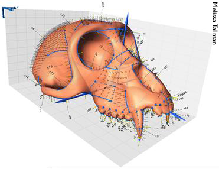

## Steps in a GM analysis

using the `geomorph` package in R

1. Get coordinate data (e.g., digitize outline from a photo, use a microscribe, get 3D coordinates from surface scanned specimen, etc)
2. Perform a Generalized Procrustes Analysis (GPA)
3. Analyze and visualze the results from the GPA

## GM - Step 1 - Coordinates

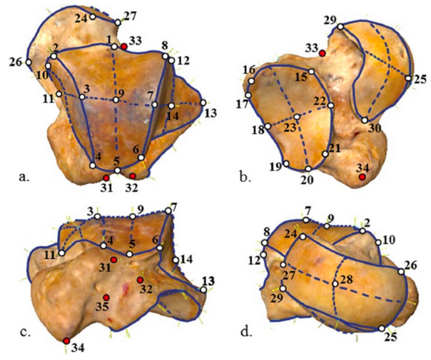

- involves capturing homologous *landmarks* or *semi-landmarks*
- can be 2D or 3D
- each specimen will have a unique *configuration* of landmarks in its own coordinate system

## GM - Step 1 - Coordinates

We will use 2D coordinate data of salamander head shape stored in the `plethspecies` variable

note that the landmark data is in a \(p\ (landmarks) \times k \ (dimensionality) \times n\ (individuals)\) array

```r
library(geomorph)
data(plethspecies)
plethspecies$land[,,1]
```

```
##              [,1]         [,2]
##  [1,]  0.21709112 -0.000276374
##  [2,]  0.25926598 -0.052804288
##  [3,] -0.01647032 -0.016116581
##  [4,] -0.25610814 -0.122293605
##  [5,] -0.27985971 -0.091408103
##  [6,] -0.31518457 -0.062484078
##  [7,] -0.31617380  0.011871093
##  [8,] -0.18628522  0.091895157
##  [9,]  0.03922964  0.119902699
## [10,]  0.23104389  0.103313314
## [11,]  0.62345113  0.018400765
```

## GM - Step 1 - Coordinates

Notice that our `plethspecies` has more than landmarks, it also has a phylogenetic tree

We will explore these more next week, but just take brief look

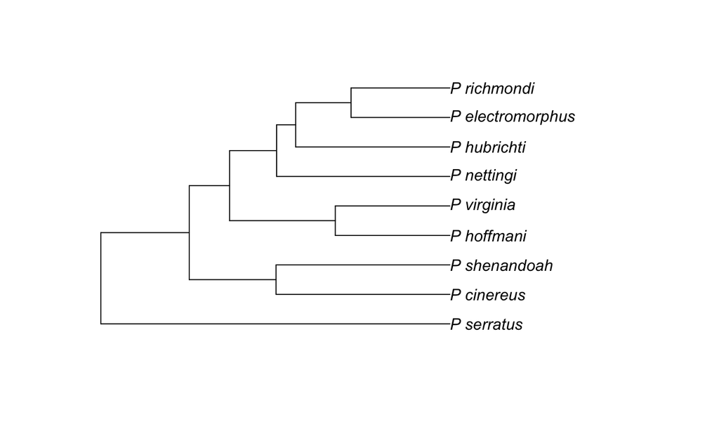

```r
plot(plethspecies$phy)
```

## GM - Step 2 - Procrustes

[figure not shown]

## GM - Step 2 - Procrustes

- Translates all configurations to the origin
- scales them to centroid size
- rotates them until the *Procrustes distance* between configurations is minimized

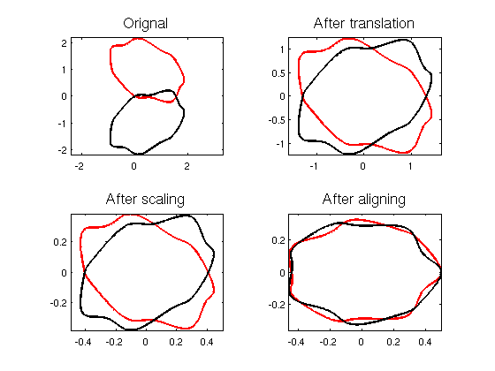

## GM - Step 2 - Procrustes

```r
GPA_pleth <- gpagen(plethspecies$land)
```

```r
GPA_pleth
```

```
##
## Call:
## gpagen(A = plethspecies$land)
##
##
##
## Generalized Procrustes Analysis
## with Partial Procrustes Superimposition
##
## 11 fixed landmarks
## 0 semilandmarks (sliders)
## 2-dimensional landmarks
## 2 GPA iterations to converge
##
##
## Consensus (mean) Configuration
##
##              X           Y
## 1   0.21321198 -0.02105584
## 2   0.24769363 -0.08046387
## 3  -0.02712554 -0.01550055
## 4  -0.26228896 -0.09485409
## 5  -0.29017433 -0.06350496
## 6  -0.31712433 -0.03118322
## 7  -0.31143955  0.04394055
## 8  -0.17573253  0.10754464
## 9   0.05243877  0.11186878
## 10  0.24134839  0.07648746
## 11  0.62919248 -0.03327890
```

## GM - Step 3 - Do PCA

```r
PCA <- gm.prcomp(GPA_pleth$coords)
summary(PCA)
```

```
##
## Ordination type: Principal Component Analysis
## Centering by OLS mean
## Orthogonal projection of OLS residuals
## Number of observations: 9
## Number of vectors 8
##
## Importance of Components:
##                               Comp1        Comp2        Comp3        Comp4
## Eigenvalues            0.0002720474 0.0001120524 0.0001084758 0.0000568924
## Proportion of Variance 0.4564029477 0.1879858086 0.1819855633 0.0954461044
## Cumulative Proportion  0.4564029477 0.6443887563 0.8263743196 0.9218204240
##                               Comp5        Comp6        Comp7        Comp8
## Eigenvalues            0.0000264508 1.260516e-05 5.959622e-06 1.584785e-06
## Proportion of Variance 0.0443754550 2.114717e-02 9.998220e-03 2.658730e-03
## Cumulative Proportion  0.9661958790 9.873431e-01 9.973413e-01 1.000000e+00
```

## GM - Step 3 - Plot PCA

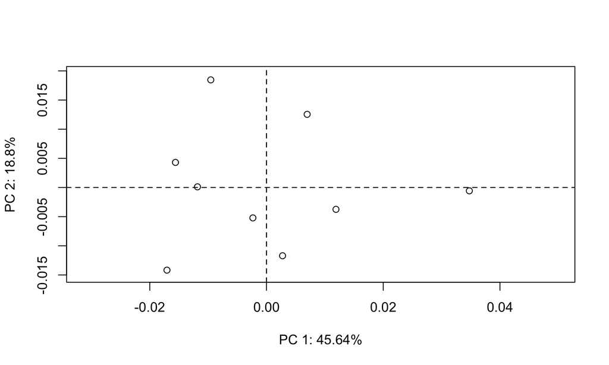

```r
plot(PCA)
```

## Alternatively plot phylomorphospace

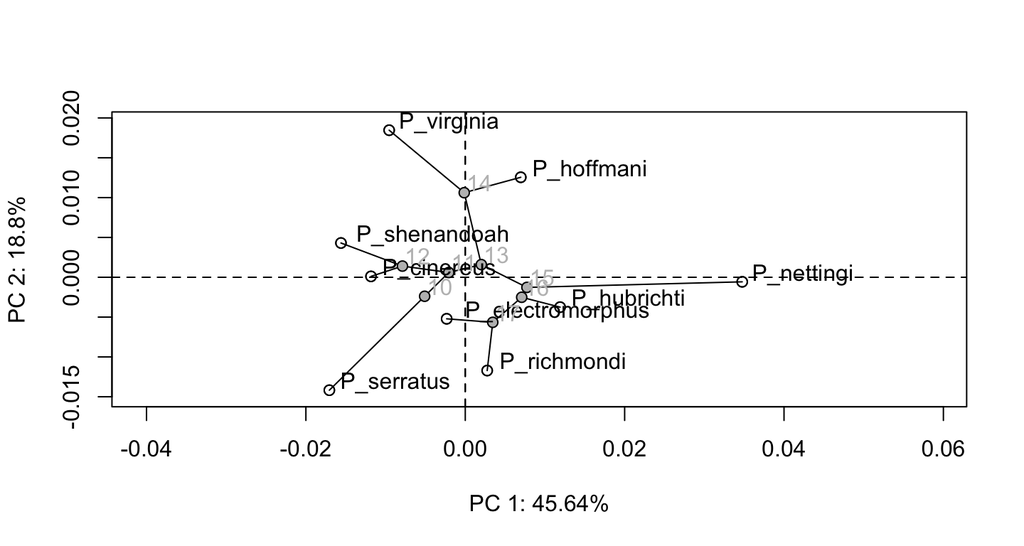

```r
PCA_phylo <- gm.prcomp(GPA_pleth$coords, phy = plethspecies$phy)
plot(PCA_phylo, phylo = TRUE)
```

Check out the `picknplot.shape()` for help visualizing the grids

## GM - Step 3 - Further Analyze and Visualize

you can do TONS of analyses using the functions in the `geomorph` package

Questions?